# Лабораторная работа № 2

## УТОЧНЕНИЕ ПРИБЛИЖЕННОГО КОРНЯ УРАВНЕНИЯ МЕТОДОМ ХОРД, МЕТОДОМ КАСАТЕЛЬНЫХ (НЬЮТОНА), МОДИФИЦИРОВАННЫМ МЕТОДОМ НЬЮТОНА, МЕТОДОМ СЕКУЩИХ, КОМБИНИРОВАННЫМ МЕТОДОМ

### Цель работы:

изучить численные методы уточнения корней уравнений: метод хорд, метод касательных, модифицированный метод касательных, метод секущих, комбинированный метод; вычислить предложенными методами с точностью до $\epsilon = 10^{-5}.$ действительный корень заданного алгебраического уравнения $f(x) = 0$.

## Постановка задачи

1. Отделить корни для заданного алгебраического уравнения $f(x) = 0$. Для решения этой задачи использовать графический метод.
2. Решить задачу уточнения корня, используя комбинированный метод (ручной счет).
3. Решить задачу уточнения корней уравнения с заданной точностью $\epsilon = 10^{-5}.$ , используя метод хорд, метод касательных, модифицированный метод касательных, метод секущих, комбинированный метод в пакете МATHCAD, записав соответствующие программные блоки.
4. Решить задачу уточнения корней предложенными методами с заданной точностью в среде MATLAB.
5. Проверить правильность результатов с помощью встроенных функций пакетов.
6. Свести все полученные результаты в таблицу, сделать выводы о скорости сходимости использованных методов, оценить погрешность результата, используя теорему о погрешности приближенного корня.

## Содержание отчета

1. Постановка задачи.
2. Теоретические сведения: расчетные формулы и геометрическая интерпретация для каждого метода.
3. Три-четыре итерации комбинированного метода для заданного уравнения (ручной счет).
4. Результаты счета на ЭВМ.
5. Выводы.

## Теоретические сведения

### Метод линейной интерполяции (метод хорд).

Пусть дано уравнение $$f(x) = 0, (2.1)$$ где функция $f(x)$ непрерывна на $[a, b]$ и $f(a)\cdot f(b) \lt 0$ ( $f(a)$ and $f(b$). Тогда, вместо того чтобы делить отрезок $[a, b]$ пополам (как это делается в методе половинного деления), более естественно поделить его в отношении $\frac{f(a)}{f(b)}$. TЭто дает приближенное значение корня $x_{0} = b + h_{1}$, где

$$h_{1} = \frac{- f(b)}{f(a) - f(b)}(a - b) = -\frac{f(b)(a - b)}{f(a) - f(b)}.$$

Далее, применив этот прием к тому из отрезков ($[a, x_{0}]$ or $[x_{0}, b]$), на концах которого функция $f(x)$ имеет противоположные знаки, получим второе приближение корня $x_{2}$ и т.д.

Геометрически способ пропорциональных частей эквивалентен замене кривой $y = f(x)$ хордой, проходящей через точки A $(a; f(a))$ и B $(b; f(b))$ (рис. 2.1).

[figure not shown]

Рис. 2.1. Геометрическая интерпретация метода хорд

В самом деле, уравнение хорды AB есть $$\frac{x - b}{a - b} = \frac{y - f(b)}{f(a) - f(b)}.$$

Отсюда, полагая $x = x_{0}$ и $y = 0$, получаем $$x_{0} = b - \frac{f(b)(a - b)}{f(a) - f(b)}.$$

Для сходимости метода хорд необходимо, чтобы выполнялись следующие условия:

1. Неподвижен тот конец хорды, для которого знак функции $f(x)$ совпадает со знаком ее второй производной $f''(x)$;
2. Последовательные приближения $x_{n}$ лежат по ту сторону корня $\xi$ где функция $f(x)$ имеет знак, противоположный знаку ее второй производной $f''(x)$.

Расчетная формула метода в случае неподвижной точки a:

$$x_{n} = x_{n-1} - \frac{f(x_{n-1})(a - x_{n-1})}{f(a) - f(x_{n-1})}.$$

Если отрезок $[a, b]$ достаточно мал, то погрешность метода определяется так: $|\xi - x_{n}| \lt |x_{n} - x_{n-1}|$ Таким образом, в этом случае, как только будет выполняться условие $|x_{n} - x_{n-1}| \lt \epsilon$, где $\epsilon$ – заданная предельная абсолютная погрешность, гарантировано, что $|\xi - x_{n}| \lt \epsilon$.

### Метод Ньютона (метод касательных).

Пусть $\xi$ – корень уравнения $f(x) = 0$ – отделен на отрезке $[a, b]$, причем $f’(x)$ и $f’’(x)$ непрерывны и сохраняют определенные знаки при $a \leq x \leq b$. Положим $\xi = x_{n} + h_{n}$, где $h_{n}$ считаем малой величиной. Отсюда, применив формулу Тейлора, получим $0 = f(x_{n} + h_{n}) \approx f(x_{n}) + h_{n}f'(x_{n})$

Следовательно,

$$h_{n} = -\frac{f(x_{n})}{f'(x_{n})}.$$

Внеся эту поправку в формулу уточнения корня, можно найти следующее (по порядку) приближение корня:

$$x_{n+1} = x_{n} - \frac{f(x_{n})}{f'(x_{n})}.$$ (n=0,1,2,3...)

Геометрически метод Ньютона эквивалентен замене небольшой дуги кривой y = f(x) касательной, проведённой в некоторой точке кривой (рис. 2.2).

[figure not shown]

Рис. 2.2. Геометрическая интерпретация метода Ньютона

$\underline{Теорема}$. Если $f(a)\cdot f(b) \lt 0$, причем $f'(x)$ andи $f''(x)$ отличны от нуля и сохраняют определенные знаки при $a \le x \le b$, то, исходя из начального приближения $x_{0} \in [a, b]$ то, исходя из начального приближения $f(x_{0})\cdot f''(x_{0}) \gt 0$, можно вычислить методом Ньютона.

$$x_{n+1} = x_{n} - \frac{f(x_{n})}{f'(x_{n})}.$$

единственный корень $\xi$ уровнения $f(x) = 0$ с любой степенью точности.

Применяя метод Ньютона, следует руководствоваться следующим правилом: в качестве исходной точки $x_{0}$ выбирается тот конец интервала $[a, b]$ , которому отвечает ордината того же знака, что и знак $f''(x)$. Условием завершения итерационного процесса является выполнение неравенства $|x_{n} - x_{n-1}| \lt \epsilon$ где $\epsilon$ – заданная предельная абсолютная погрешность.

### Модифицированный метод Ньютона.

Если производная $f’(x)$ мало изменяется на отрезке $[a, b]$, то в расчетной формуле метода касательных можно положить $f'(x_{n})\approx f'(x_{n})$ .
Отсюда для корня $\xi$ уравнения $f(x) = 0$ получаем последовательные приближения $$x_{n+1} = x_{n} - \frac{f(x_{n})}{f'(x_{0})}.$$ (n=0,1,2...) Геометрически этот способ означает, что заменяются касательные в точках $B_{n}[x_{n}, f(x_{n})]$ прямыми, параллельными касательной к кривой $y = f(x)$, в её фиксированной точке $B_{0}[x_{0}, f(x_{0})]$ (рис. 2.3). Эта формула весьма полезна, если $f'(x)$ сложна.

[figure not shown]

Рис. 2.3. Геометрическая интерпретация модифицированного метода Ньютона

### Комбинированный метод.

Метод, используемый для вычисления значения корня с заданной точностью, заключается в поочередном применении метода хорд и метода касательных. Концы отрезка, содержащего корень уравнения, обозначим $a_{0}$ и $b_{0}$. Условимся обозначать через $a_{0}$ тот конец отрезка, на котором знаки функции $f(x)$ и её второй производной $f''(x)$ совпадают. Через точки $[a_{0}, f(a_{0})], [b_{0}, f(b_{0})]$. проведём хорду. Точку пересечения хорды с осью Ох обозначим через $b_{1}$. В точке $[b_{0}, f(b_{0})]$ проведём касательную к кривой $y = f(x)$. Точку пересечения касательной с осью Ох обозначим через, $a_{1}$ Итак, получен новый отрезок с концами $a_{1}$ и $b_{1}$, содержащий корень уравнения (рис. 2.4). Аналогично получаем отрезок с концами $a_{2}$ и $b_{2}$, и т.д.

[figure not shown]

Расчётные формулы комбинированного метода для случая, приведенного на рис. 2.4, имеют следующий вид:

$$b_{n+1} = b_{b} - \Delta b_{n}, \Delta b_{n} = \frac{f(a_{n})(b_{n} - a_{n})}{f(b_{n} - f(a_{n}))};$$ $$a_{n+1} = a_{b} - \Delta a_{n}, \Delta a_{n} = \frac{f(a_{n})}{f'(a_{n}))}.$$

где n=0,1,... . Если корень уравнения требуется вычислить с точностью до $\epsilon$, то процесс вычисления корня можно прекращать в тот момент, когда $|b_{n} - a_{n}| \lt 2\epsilon$. В качестве ответа взять среднее арифметическое последних полученных значений $a_{n}$ и $b_{n}$, т.е.

$$\xi = \frac{a_{n} + b_{b}}{2}.$$

### Погрешность численного решения уравнения.

Для оценки точности приближения можно воспользоваться формулой $$|x_{n} - \xi| \le \frac{f(x_{n})}{m_{1}}, |f'(x)| \ge m_{1}, a \le x \le b.$$

Приведем еще формулу, позволяющую оценивать абсолютную погрешность приближенного значения $x_{n}$, если известны два последовательных приближения $x_{n-1}$ и $x_{n}$. Будем предполагать, что производная $f'(x)$ непрерывна на отрезке $[a, b]$, содержащем все приближения, и сохраняет постоянный знак, причем

$$0 \lt m_{1} \le |f'(x)| \lt M \lt +\infty.$$

Примем для определенности, что последовательные приближения $x_{n}$ точного корня $\xi$ вычисляются по формуле

$$x_{n} = x_{n-1} - \frac{f(x_{n-1})}{f(x_{n-1}) - f(a))}(x_{n-1} - a), n = (1, 2, ...),$$

где конец является неподвижным. Отсюда будем иметь

$$f(\xi) - f(x_{n-1}) = \frac{f(x_{n-1}) - f(a)}{x_{n-1} - a}(x_{n} - x_{n-1}).$$

Применив теорему Лагранжа о конечном приращении функции, получим

$$(\xi - x_{n-1})f'(\xi_{n-1}) = (x_{n} - x_{n-1})f'(\overline{x_{n-1}}),$$

где $\xi_{n-1} \in (x_{n-1}, \xi)$ и $\overline{x_{n-1} \in (a, x_{n-1})}$. Следовательно,

$$|\xi - x_{n}| = \frac{|f'(\overline{x_{n-1}}) - f(\xi_{n-1})|}{|f'(\xi_{n-1})|}|x_{n} - x_{n-1}|. (2.1)$$

Поскольку $f'(x)$ сохраняет постоянный знак на отрезке $[a, b]$, причем $\overline{x_{n-1}} \in [a, b]$ и $\xi_{n-1} \in [a, b],$, то, очевидно, имеем

$$|f'(\overline{x_{n-1}}) - f'(\xi_{n-1})| \le M_{1} - m_{1}.$$

Из выражения (2.1) выводим формулу

$$|\xi - x_{n}| \le \frac{M_{1} - m_{1}}{m_{1}}|x_{n} - x_{n-1}|, (2.2)$$

где за $m_{1}$, $M_{1}$ могут быть взяты соответственно наименьшее и наибольшее значения модуля производной $f'(x)$ на отрезке $[a, b]$. Если отрезок столь узок, что имеет место неравенство $M_{1} \le 2m_{1}$ то из формулы (2.2) получаем

$$|\xi - x_{n}| \le |x_{n} - x_{n-1}|.$$

## Примеры выполнения заданий

### Уточнение корня комбинированным методом.

Вычислить с точностью до $\epsilon = 10^{-3}$ действительный корень уравнения $x^{3} + 3x + 8 = 0$.

Рассмотрим $$f(x) = x^{3} + 3x + 8.$$ На отрезке$[-2, -1]$ содержится корень заданного уравнения, так как на концах этого отрезка функция $f(x)$ имеет разные знаки: $$f(-2) = -6, f(-1) = 4.$$ Производная $f'(x) = 3x^{2} + 3 \gt 0$ при всех, поэтому уравнение $x^{3} + 3x + 8 = 0$ имеет единственный действительный корень. Таким образом, на отрезке $[-2, -1]$ находится единственный действительный корень уравнения. Вторая производная $f''(x)=6x<0$ при $-2<=x<=-1$ , поэтому через $b_{0}$ обозначаем конец отрезка x=-2, т.е. $b_{0}=-2$, $a_{0}=-1$. Дальнейшие вычисления оформляем в виде таблицы:

[figure not shown]

Пример взят из пособия С.В. Михайленко «Прикладная математика».

## Пример вычислений

Импортируем математический модуль

```python
from math import fabs
```

Обьявление начальных значений и значение функций

```python
# initial values
a, b, eps = -2, -1, 1e-3
```

```python
# function f(x)
def f(x):
    return x**3 + 3*x + 8
```

```python
# derivative of f(x)
def df(x):
    return 3*x**2 + 3
```

Создаем функцию уточнения приближенного корня уравнения методом хорд("chord_method") использываем цыкл "while". Более подробную информацию о Python можно узнать тут: https://pythonworld.ru/tipy-dannyx-v-python/vse-o-funkciyax-i-ix-argumentax.html

```python
def chord_method(a, b, eps):
    n = 0
    while fabs(b - a) > eps:
        a = b - (b - a) * f(b) / (f(b) - f(a))
        b = a + (a - b) * f(a) / (f(a) - f(b))
        n += 1
    return (b, n)
```

```python
Выводим результат функции
```

```python
print(chord_method(a, b, eps))
```

```
(-1.5131498333591615, 3)
```

```python
Аналогично создаем функцию метода Ньютона("newton_method") и Комбинированного метода("combined_method")
```

```python
def newton_method(a, b, eps):
    n = 0
    b = a - f(a) / df(a)
    while fabs(b - a) > eps:
        a = b
        b -= f(b) / df(b)
        n += 1
    return (b, n)
```

```python
print(newton_method(a, b, eps))
```

```
(-1.5127453266306898, 3)
```

```python
def combined_method(a, b, eps):
    n = 0
    while fabs(b - a) > eps:
        a -= f(a) / df(a)
        b -= f(b) * (a - b) / (f(a) - f(b))
        n += 1
    return ( (a + b) / 2, n)
```

```python
print(combined_method(a, b, eps))
```

```
(-1.5127479184413737, 3)
```

Для построения графика импортируем "matplotlib" Подробную информация о графиках на Python можно посмотреть по ссылкам: https://devpractice.ru/python-lesson-6-work-in-jupyter-notebook/ https://eax.me/python-matplotlib/

```python
from matplotlib.pyplot import plot
import numpy as np
```

```python
xn = np.arange(a, b, 1e-1)
y = [f(x) for x in xn]
```

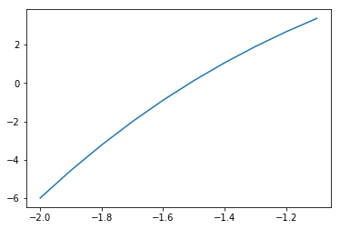

```python
plot(xn, y)
```